# COURSERA - JHU Swiftkey Capstone Project

Gito

2024-11-25

# Executive Summary

This Project is part of Coursera - John Hopkins Data Science Specialization Course on Swiftkey Capstone Project.

This Project is about predicting/suggesting next text/word based on the given text/sentences, like popular phone Swiftkey Smart Keyboard.

The N-Gram result was already summarized from Task02 Project based on collections of 3 training datasets, en_US.blogs.txt,en_US.twitter.txt and en_US.news.txt which then pre-processed to be N-Gram tables.

**Algorithm Steps :**

1. Data Collections from News,Blogs and Twitter and Data Cleaning
2. NLP Analysis to produce n-Gram, in this project we will use mono,bi and tri-Gram to predict up to 2 word predictors
3. Generate 5 highest frequency n-gram
4. Filter up to 2 words input to predict 2nd/3rd words based on 5 highest likelihood
5. System View

# Data Collections and Data Cleaning

Below are the steps of Data Collections and Data Cleaning

- Import Data From the given sources,ie Twitter, blogs and news
- Data Cleaning and transform to word corpus, which consists of remove unnecessary characters, remove punctuation, remove numbers, transform to lowercase and text stemming
- Below are sample output of Top 20 Monogram, Bigram and Trigram respectively
- This results will be used to predict/recommend next words based on 2 last word predictors

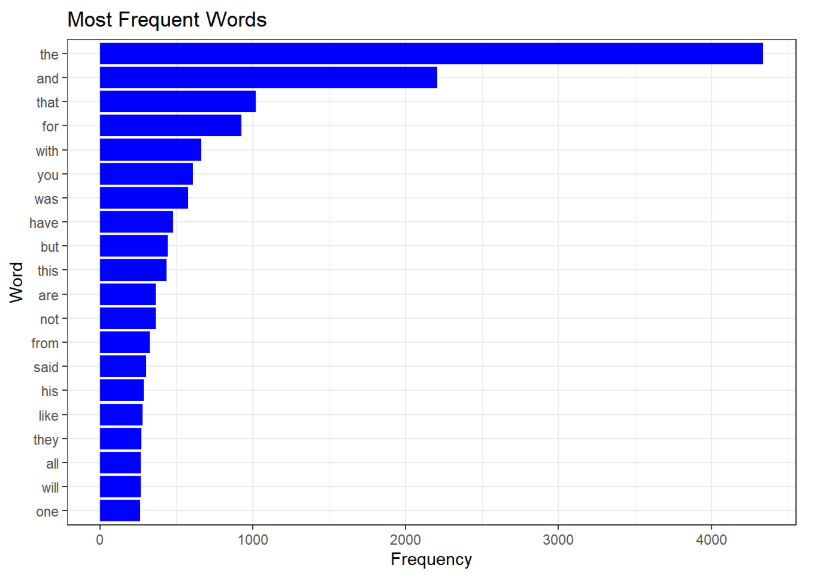

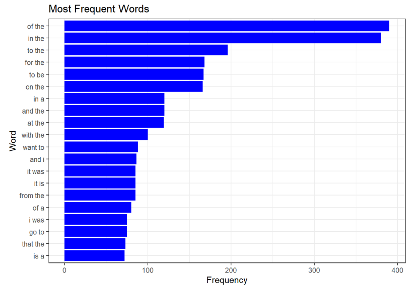

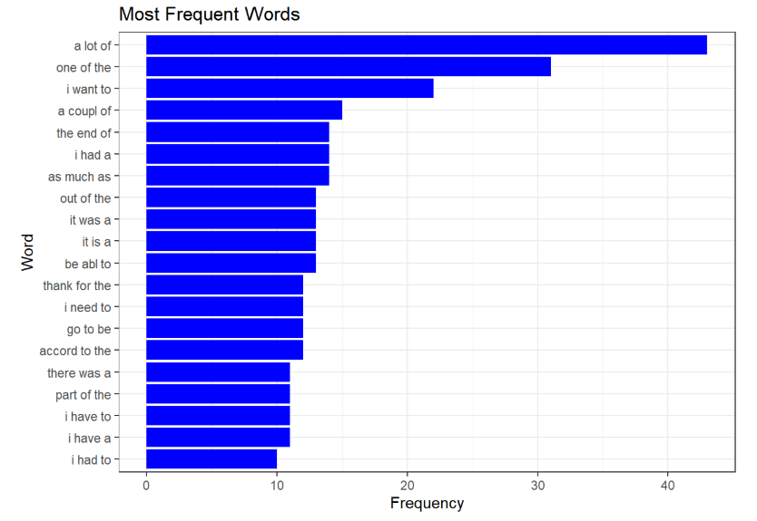

# Filtering, Predictions Result and Limitations

Predictions will be made based on the mono,bi and tri-gram tables from the given input predictors

Below are project limitations and limitations could be further enhanced as per required.

- Training data was limited to 7500 rows to avoid memory overload issues
- Predictors are limited to max last 2 words
- Output predictions will be limited to 5 predictions based on highest likelihood

# System View

Below are graphical interface on shiny apps

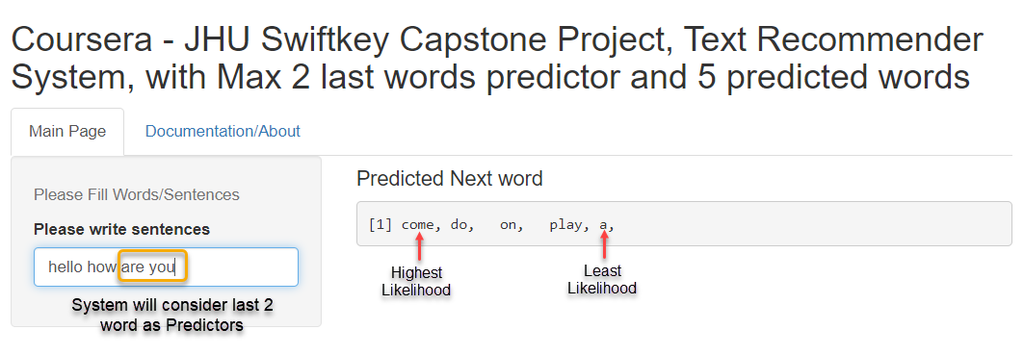